# Mi primer R markdown

Dr. Oscar De la Torre

2023-09-26

# Título 1

Este es un texto de párrafo.

## Subtítulo 1

**Este es texto en negritas** y esto otro es *texto en itálica*. Esta es una nota al pie[^1]

En este subtítulo generamos 250 números aleatorioa con media de cero $\bar{X}=0$ y desviación estándar $s_X=1$

```r
# Se generan los números aleatorios
media=0
desvEst=1
n=250
X=rnorm(n,media,desvEst)
# Se imprimen solo los 10 primeros números en pantalla:
head(X,10)
```

```
##  [1] -0.2058292  1.3045734  2.4000285 -1.1130874 -0.3007326  1.0273811
##  [7]  1.2002862  0.4506371 -1.3933139 -1.4914341
```

En el siguiente código, creamos una gráfica sencilla del objeto $X$ con los números aleatorios:

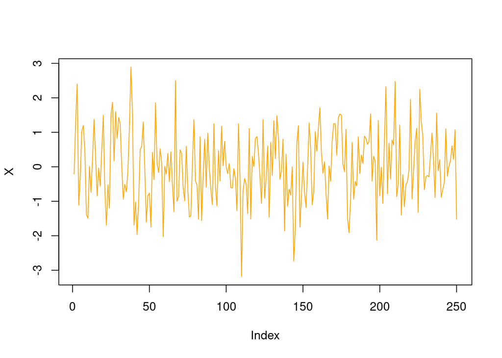

## Subtítulo 2

Más texto… $y=3$

En esta parte conoceremos cómo descargar datos de las bases del Sistema de Información Económica (SIE) del Banco de México, directo a nuestra computadora. Lo primero que se ocupa es una llave de API o API key [el mismo se obtiene en esta liga](https://www.banxico.org.mx/SieAPIRest/service/v1/;jsessionid=8dab734a3408a498e31ce76789a3):

```r
token="1f8b943c454f9b95e5f13c752aaa63b6528b9de24365b9593e659cdff343c2f9"
```

Es necesario instalar la librería o paquete siebanxicor con este comando (en la consola):

install.packages(“siebanxicor”)

```r
# Invocamos la librería siebanxicor:
library("siebanxicor")

# Cargamos en la memoria el token de consulta:
setToken(token)

# Identificamos las serie o series (código) de los datos que queremos cargar:

idSeries=c("SF63528")

series <- getSeriesData(idSeries, '2020-01-01','2023-01-31')

# Ya que se descargó el objeto "series", lo convertimos a una objeto data.frame:
datosTC=data.frame(
  fecha=series$SF63528$date,
  valor=series$SF63528$value
)
```

Ahora, hacemos una gráfica del tipo de cambio histórico:

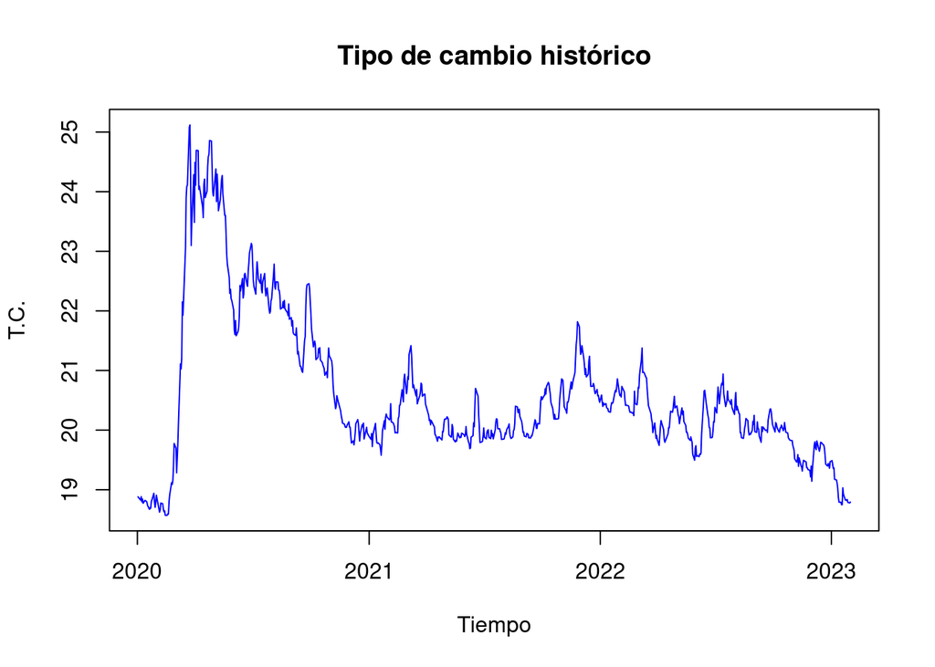

```r
plot(x=datosTC$fecha,
     y=datosTC$valor,
     type="l",
     col="blue",
     main="Tipo de cambio histórico",
     xlab="Tiempo",
     ylab="T.C.")
```

# operadores for, while, switch e if

La sintaxis del comando u operador for es:

for (contador in [inicio]:[fin]){

Operaciones a repetir

}

Vamos a aproximar, con la fórmula del valor futuro compuesto, el número $e$:

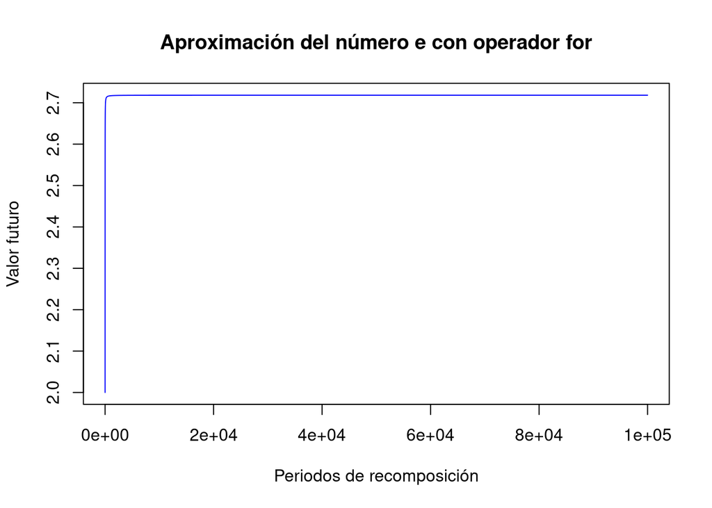

```r
# Creamos los objetos con los datos de entrada del problema:
VA=1 # Valor actual de un peso
i=1 # Tasa de interés anualizada de 100% (i=1)
paro=100000 # Número de iteraciones (cálculos) que deseamos realizar

# Con los comandos data.frame y matrix, creamos la tabla de salida:

tablaSalida=data.frame(
  n=seq(from=1,to=paro,by=1),
  VF=matrix(0,paro,1)
)
# Ejecutamos el operador for:

for (contador in 1:paro){
n=contador
VF=VA*(1+(1/n))^n

tablaSalida$VF[contador]=VF

}

# Graficamos el resultado
plot(x=tablaSalida$n,
     y=tablaSalida$VF,
     col="blue",
     type="l",
     xlab="Periodos de recomposición",
     ylab="Valor futuro",
     main="Aproximación del número e con operador for")
```

Ahora se utilizará el operador while. El mismo no tiene una cantidad definida de iteraciones, sino una condición de paro.

```r
# Creamos los objetos con los datos de entrada del problema:
VA=1 # Valor actual de un peso
i=1 # Tasa de interés anualizada de 100% (i=1)
paro=100000 # Número de iteraciones (cálculos) que deseamos realizar
VF0=1 # El valor inicial del VF en la iteración
umbral=0.000000000001 # Asigno un valor de umbral
DeltaVF=Inf # Asigno un valor inicial del incremento del VF en cad iteración
n=0 # Valor inicial a n en la iteraciones

# Operador while:
while (DeltaVF>umbral){
  # Actualizo el valor de n, seún el número de iteración realizado:
  n=n+1
  # Calculo el valor futuro:
  VF=VA*(1+(1/n))^n
  # Actualizamos el incremento del valor futuro de esta iteración con el de la iteración anterior (VF0):
  DeltaVF=VF-VF0
  # Actualizo el valor futuro de esta iteración como el valor futuro "de la iteración anterior" para futuras iteraciones:
  VF0=VF
}

VF
```

```
## [1] 2.718272
```

```r
DeltaVF
```

```
## [1] -1.084022e-12
```

```r
n
```

```
## [1] 132361
```

Operador “switch”

```r
equipo="Tigres"

switch(
  equipo,
  "América"={respuesta="Nadie es perfecto..."},
  "Chivas"={respuesta="Mejor búscate otro deporte..."},
  "Morelia"={respuesta="¿Es equipo?"},
  "Atlas"={respuesta="No seas fresa..."},
  {respuesta="Sabes de fútbol..."}
)
respuesta
```

```
## [1] "Sabes de fútbol..."
```

Operador if

```r
calificacion=7

if (calificacion>8){
  respuesta="Buen trabajo, Usted estudió mucho..."
} else {

  if (calificacion<6){
    respuesta="Usted debe estudiar más..."
  } else {
    respuesta="Puede mejorar su trabajo..."
  }

}
respuesta
```

```
## [1] "Puede mejorar su trabajo..."
```

# Creando funciones en R

```r
# Se crea (se programa) la función:
VFfuncion=function(umbral){

# Creamos los objetos con los datos de entrada del problema:
VA=1 # Valor actual de un peso
i=1 # Tasa de interés anualizada de 100% (i=1)
#paro=100000 # Número de iteraciones (cálculos) que deseamos realizar
VF0=1 # El valor inicial del VF en la iteración
#umbral=0.000000000001 # Asigno un valor de umbral
DeltaVF=Inf # Asigno un valor inicial del incremento del VF en cad iteración
n=0 # Valor inicial a n en la iteraciones

# Operador while:
while (DeltaVF>umbral){
  # Actualizo el valor de n, seún el número de iteración realizado:
  n=n+1
  # Calculo el valor futuro:
  VF=VA*(1+(1/n))^n
  # Actualizamos el incremento del valor futuro de esta iteración con el de la iteración anterior (VF0):
  DeltaVF=VF-VF0
  # Actualizo el valor futuro de esta iteración como el valor futuro "de la iteración anterior" para futuras iteraciones:
  VF0=VF
}

# Creamos el objeto tipo lista de salida:
respuesta=list(
VF=VF,
DeltaVF=DeltaVF,
N=n
)
# Se imprime el mensaje de salida:
print(
  paste0("Después de ",n," iteraciones, ",
         "se llegó a un VF de ",VF,", dado el umbral de",
         umbral," que llevó a un valor de DeltaVF de ",DeltaVF)
  )
# Se regresa el objeto de salida al environment para que se encuentre disponible ahí:
return(respuesta)
}
```

Corremos la función cargada en la memoria RAM (chunk previo):

```r
# Corremos la función:
umbralPrueba=0.0000000000000000001
miRespuesta=VFfuncion(umbralPrueba)
```

```
## [1] "Después de 132361 iteraciones, se llegó a un VF de 2.71827156005115, dado el umbral de1e-19 que llevó a un valor de DeltaVF de -1.084021761244e-12"
```

Aquí se invoca la función desde el archivo *.R que se cró en nuestra computadora o en la carpeta orepositorio de un servicio de nube como Dropbox, OneDrive, Google drive y, mejor aún, un repositorio de GitHub (que es lo mejor).

```r
source("VFfuncion.R")
# Corremos la función:
umbralPrueba=0.0000000000000000001
miRespuesta=VFfuncion(umbralPrueba)
```

```
## [1] "Después de 132361 iteraciones, se llegó a un VF de 2.71827156005115, dado el umbral de1e-19 que llevó a un valor de DeltaVF de -1.084021761244e-12"
```

## Cargando la función desde GitHub

```r
source("https://raw.githubusercontent.com/OscarVDelatorreTorres/VFfuncion2023/main/VFfuncion.R")

# Corremos la función:
umbralPrueba=0.0000000000000000001
miRespuesta=VFfuncion(umbralPrueba)
```

```
## [1] "Después de 132361 iteraciones, se llegó a un VF de 2.71827156005115, dado el umbral de1e-19 que llevó a un valor de DeltaVF de -1.084021761244e-12"
```

[figure not shown]

[^1]: Nota al pie…